# Analysis of Jane Eyre

Christian Rohrbeck

05/03/2025

```r
library(dplyr)
library(ggplot2)
library(tidytext)
library(wordcloud)
library(stringr)
```

### **Loading and cleaning the text data**

We can either download the text from Project Gutenberg (see lecture notes), or directly via the text file provided on Moodle

```r
JaneEyre_raw <- readLines( "JaneEyre.txt" )
JaneEyre_raw <- data.frame( text = JaneEyre_raw )
```

Let’s split the text into words:

```r
JaneEyre <- JaneEyre_raw %>% unnest_tokens( word, text )
```

```r
nrow(JaneEyre)
```

```
## [1] 188399
```

We have to do some data cleaning. Let’s look at the first 10 words

```r
slice_head( JaneEyre, n=10 )
```

```
##             word
## 1           jane
## 2           eyre
## 3             an
## 4  autobiography
## 5             by
## 6      charlotte
## 7         brontë
## 8   _illustrated
## 9             by
## 10             f
```

We remove the underscores from any words, as they are used to indicate words in italics

```r
JaneEyre <- JaneEyre %>% mutate( word = gsub( "\\_", "", word ) )
```

## **Word frequency analysis**

### Calculating term frequency

We now count how often each word appears in the book:

```r
JaneEyre_Count <- JaneEyre %>% count( word, sort=TRUE )
```

```r
slice_head(JaneEyre_Count, n=10 )
```

```
##    word    n
## 1   the 7856
## 2     i 7169
## 3   and 6632
## 4    to 5238
## 5     a 4470
## 6    of 4368
## 7   you 2970
## 8    in 2769
## 9   was 2526
## 10   it 2406
```

One important measure is *term frequency*:

```r
JaneEyre_Count <- JaneEyre_Count %>%
  mutate( 'term frequency'=n/sum(n), rank=row_number() ) %>%
  rename( Count = n )
```

```r
slice_head(JaneEyre_Count, n=10)
```

```
##    word Count term frequency rank
## 1   the  7856     0.04169874    1
## 2     i  7169     0.03805222    2
## 3   and  6632     0.03520189    3
## 4    to  5238     0.02780270    4
## 5     a  4470     0.02372624    5
## 6    of  4368     0.02318484    6
## 7   you  2970     0.01576441    7
## 8    in  2769     0.01469753    8
## 9   was  2526     0.01340771    9
## 10   it  2406     0.01277077   10
```

### Does Zipf’s Law hold?

Plot rank against term frequency (both on logarithmic scale):

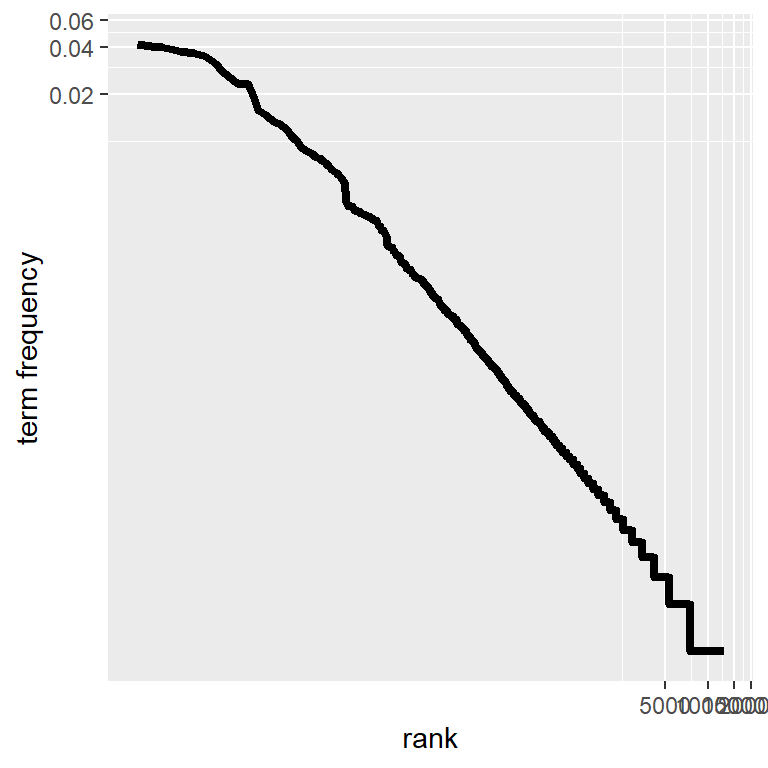

```r
ggplot( JaneEyre_Count, aes( x=rank, y=`term frequency` ) ) +
  geom_line( linewidth=1.5 ) +
  coord_trans( x="log10", y="log10" )
```

We see a linear relationship in the plot, which supports Zipf’s Law that postulates an inverse proportionality between rank and term frequency.

### Removing stop words

We use the data set **stop_words** in the tidytext package:

```r
data("stop_words")
JaneEyre_Count <- JaneEyre_Count %>%
  anti_join(stop_words, by="word")
```

```r
slice_head(JaneEyre_Count, n=10)
```

```
##         word Count term frequency rank
## 1       jane   341   0.0018099884   69
## 2  rochester   317   0.0016825992   71
## 3        sir   316   0.0016772913   72
## 4       miss   310   0.0016454440   73
## 5       time   244   0.0012951236   98
## 6        day   232   0.0012314290  102
## 7     looked   221   0.0011730423  106
## 8      night   218   0.0011571187  109
## 9       eyes   187   0.0009925743  120
## 10      john   184   0.0009766506  125
```

### Visualization

**Option 1 Bar plot:** we order the words based on frequency

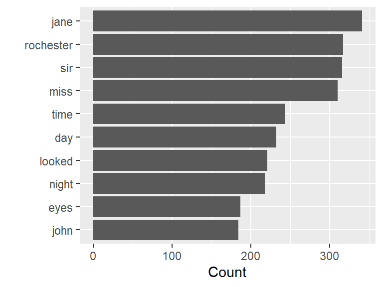

```r
JaneEyre_Count %>%
  slice_max( Count, n=10 ) %>%
  mutate( word = reorder(word,Count) ) %>%
  ggplot( aes( x=Count, y=word ) ) +
    geom_col() + labs( x="Count", y="" )
```

**Option 2 Word cloud:**

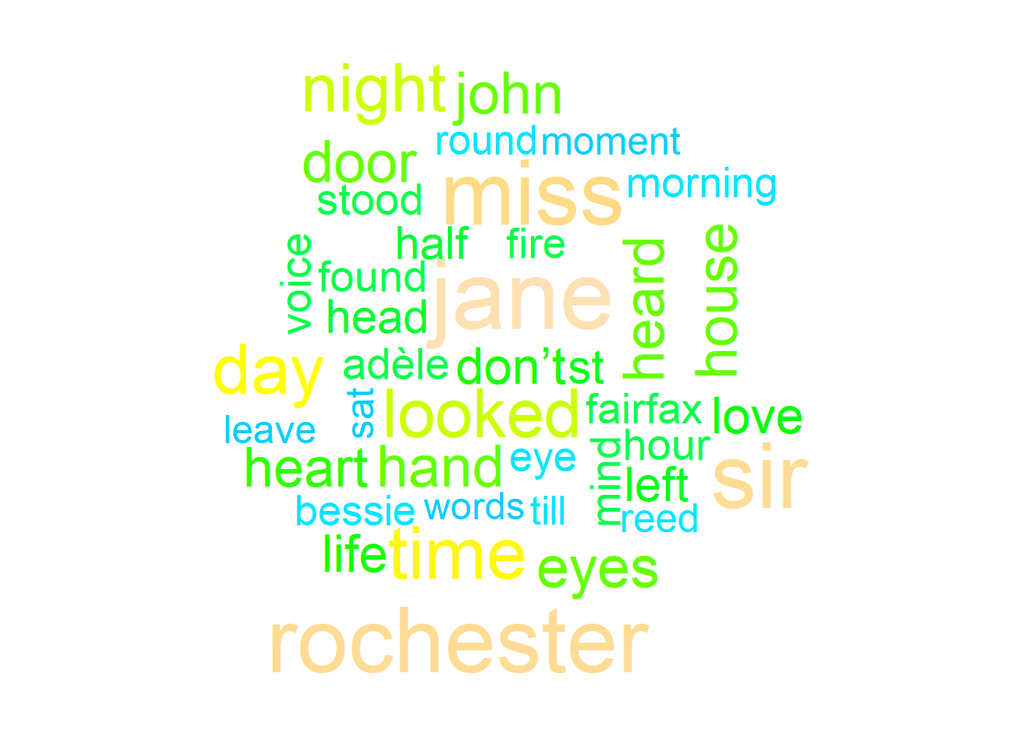

```r
JaneEyre_Count %>%
  with( wordcloud( word, Count, max.words=40, colors=topo.colors(n=40) ) )
```

## **Sentiment Analysis for** *Jane Eyre*

### Start with the raw data and split it into words

```r
JaneEyre <- JaneEyre_raw %>%
  mutate( line = row_number() ) %>%
  unnest_tokens( word, text ) %>%
  mutate( word = gsub( "_", "", word ) )
```

### Load the sentiment lexicon

```r
AFINN <- read.csv("AFINN Sentiment Lexicon.csv")
```

```r
slice_head(AFINN, n=5)
```

```
##        word value
## 1   abandon    -2
## 2 abandoned    -2
## 3  abandons    -2
## 4  abducted    -2
## 5 abduction    -2
```

### Only keep the words both in the book and the sentiment lexicon

```r
JaneEyre_AFINN <- inner_join( JaneEyre, AFINN, by="word" )
```

```r
slice_head(JaneEyre_AFINN, n=5)
```

```
##   line    word value
## 1   33 demands    -1
## 2   36  thanks     2
## 3   41    fair     2
## 4   41  honest     2
## 5   48   vague    -2
```

### Sentiment across lines

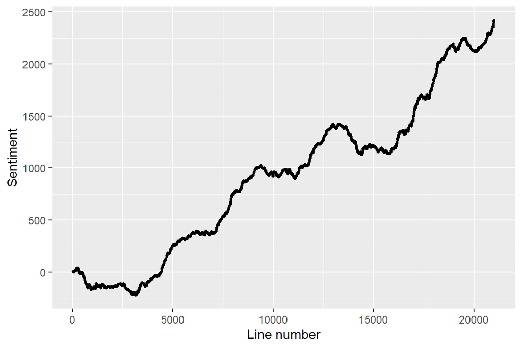

```r
JaneEyre_AFINN %>%
  filter( word != "miss" ) %>%
  mutate( sentiment = cumsum( value ) ) %>%
  ggplot( aes( x=line, y=sentiment ) ) +
  geom_line( linewidth=1.2 ) +
  labs( x="Line number", y="Sentiment" )
```

### Sentiment for the individual chapters

Detect which chapter each line belongs to:

```r
JaneEyre_chapters <- JaneEyre_raw %>%
  mutate( chapter = cumsum( str_detect(
    text, regex("^chapter ", ignore_case = TRUE)
  ) ) )
```

Remove any text before Chapter 1 and split the text into words:

```r
JaneEyre_chapters <- JaneEyre_chapters %>%
  filter( chapter > 0 ) %>%
  unnest_tokens( word, text ) %>%
  mutate( word = gsub( "_", "", word ) )
```

```r
slice_head(JaneEyre_chapters, n=5)
```

```
##   chapter    word
## 1       1 chapter
## 2       1       i
## 3       1   there
## 4       1     was
## 5       1      no
```

We can now calculate and visualize the aggregated sentiment for each chapter

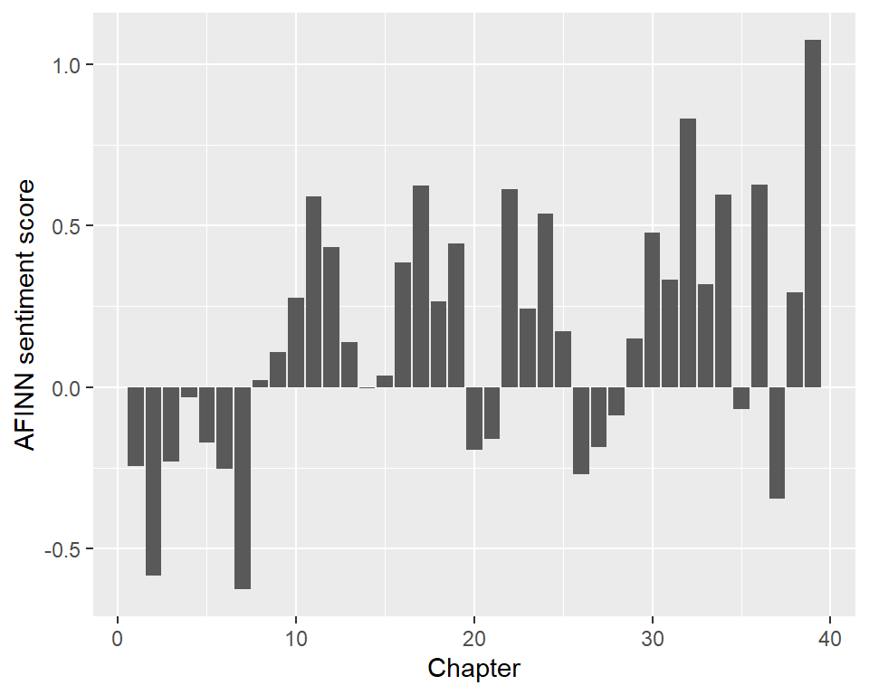

```r
JaneEyre_chapters %>%
  inner_join( AFINN, by="word" ) %>%
  group_by( chapter ) %>%
  summarise( sentiment = mean(value) ) %>%
  ggplot( aes( x=chapter, y=sentiment ) ) +
  geom_col() + labs( x="Chapter", y="AFINN sentiment score" )
```